# Practical Machine Learning

Moira Lennox

August 11, 2015

## Executive Summary

The goal of the project will be to use data from accelerometers on the belt, forearm, arm, and dumbbell of 6 participants to predict the manner in which they did the exercise.The participants were asked to perform barbell lifts correctly and incorrectly in 5 different ways. The outcome of the prediction is classified in 5 classes, one performing it correctly (class “A”) and 4 incorrectly (classes “B”, “C”, “D”, and “E”).

- Class A - exactly according to the specification
- Class B - throwing the elbows to the front
- Class C - lifting the dumbbell only halfway
- Class D - lowering the dumbbell only halfway
- Class E - throwing the hips to the front

More information is available from the website: http://groupware.les.inf.puc-rio.br/har (see the section on the Weight Lifting Exercise Dataset).

## Load Packages

```r
# get packages that are needed
library(ggplot2)
library(caret)
library(rpart)
library(randomForest)
```

## Load Data

Load the data and review the data at a highlevel.

```r
# set working directory
setwd("/Users/moiralennox/GitHub/Practical_Machine_Learning")
# load data make all blanks, null = NA
dftraining <- read.csv("./data/pml-training.csv", na.string=c("","NA","NULL"), row.names = 1)
dftesting <- read.csv("./data/pml-testing.csv", na.string=c("","NA","NULL"), row.names = 1)
dim(dftraining); dim(dftesting)
```

```
## [1] 19622   159
```

```
## [1]  20 159
```

## Clean Data & Transform

In this section I clean up the data by removing columns that have NAs and that might have other issues. Making sure columns are numeric and vectors have be converted and removing the first 6 columns that are more metadata than actual attributes about the data. Then I run the near zero variance function to find predictors that might have only a handful of unique values that occur with very low frequencies, since these columns can cause the model to fail or be unstable. There are no NZVs so all columns will be kept.

```r
dfcleanData <- dftraining[,which(as.numeric(colSums(is.na(dftraining)))==0)]
dfcleanData <- dfcleanData[,-c(1:6)]

dfcleanDataTest <- dftesting[,which(as.numeric(colSums(is.na(dftraining)))==0)]
dfcleanDataTest <- dfcleanDataTest[,-c(1:6)]
# Remove near zero covariates
NZV <- nearZeroVar(dfcleanData, saveMetrics=TRUE)
# They are all False so no they are good to keep them all.
```

## Splitting Data into Testing and Cross-Validation

The seed was set for reproducible and then the training data was divided into two parts, one for training (60%) and the other for testing(40%). The data was partioned by the “classe” variable to ensure the training set and test set contain examples of each class.

```r
set.seed(1234)
index_train <- createDataPartition(y=dfcleanData$classe, p=0.60, list=FALSE)
data_train <- dfcleanData[index_train,]
data_xval <- dfcleanData[-index_train,]
dim(data_train);dim(data_xval)
```

```
## [1] 11776    53
```

```
## [1] 7846   53
```

## Model 1: Classification Trees (method = rpart)

The classification trees model was initially used to do prediction with no preprocessing and cross validation. I decide to run just the basic model to see what happens.

```r
modFit <- train(classe ~ .,method="rpart",data=data_train)
print(modFit)
```

```
## CART
##
## 11776 samples
##    52 predictor
##     5 classes: 'A', 'B', 'C', 'D', 'E'
##
## No pre-processing
## Resampling: Bootstrapped (25 reps)
## Summary of sample sizes: 11776, 11776, 11776, 11776, 11776, 11776, ...
## Resampling results across tuning parameters:
##
##   cp          Accuracy   Kappa       Accuracy SD  Kappa SD
##   0.03618889  0.5232124  0.38448962  0.02470143   0.03890642
##   0.06110584  0.4018777  0.18592797  0.06028161   0.09852178
##   0.11651637  0.3320531  0.07413223  0.04188912   0.06186040
##
## Accuracy was used to select the optimal model using  the largest value.
## The final value used for the model was cp = 0.03618889.
```

```r
#

# show the top 20 most important variables
modFitImp <- varImp(modFit, scale = FALSE)
modFitImp
```

```
## rpart variable importance
##
##   only 20 most important variables shown (out of 52)
##
##                   Overall
## pitch_forearm      1235.0
## roll_forearm        920.5
## roll_belt           898.0
## magnet_dumbbell_y   655.7
## yaw_belt            551.8
## accel_belt_z        548.9
## magnet_belt_y       513.3
## total_accel_belt    465.3
## magnet_arm_x        320.4
## accel_arm_x         309.6
## roll_dumbbell       238.5
## magnet_dumbbell_x   235.2
## magnet_dumbbell_z   227.4
## accel_dumbbell_y    202.4
## roll_arm            197.4
## magnet_forearm_z      0.0
## gyros_forearm_z       0.0
## gyros_belt_z          0.0
## pitch_dumbbell        0.0
## accel_forearm_z       0.0
```

```r
print(modFit$finalModel)
```

```
## n= 11776
##
## node), split, n, loss, yval, (yprob)
##       * denotes terminal node
##
##  1) root 11776 8428 A (0.28 0.19 0.17 0.16 0.18)
##    2) roll_belt< 130.5 10774 7436 A (0.31 0.21 0.19 0.18 0.11)
##      4) pitch_forearm< -34.55 919    2 A (1 0.0022 0 0 0) *
##      5) pitch_forearm>=-34.55 9855 7434 A (0.25 0.23 0.21 0.2 0.12)
##       10) magnet_dumbbell_y< 436.5 8314 5944 A (0.29 0.18 0.24 0.19 0.11)
##         20) roll_forearm< 122.5 5137 3022 A (0.41 0.18 0.18 0.17 0.061) *
##         21) roll_forearm>=122.5 3177 2124 C (0.08 0.18 0.33 0.23 0.18) *
##       11) magnet_dumbbell_y>=436.5 1541  743 B (0.033 0.52 0.039 0.23 0.18) *
##    3) roll_belt>=130.5 1002   10 E (0.01 0 0 0 0.99) *
```

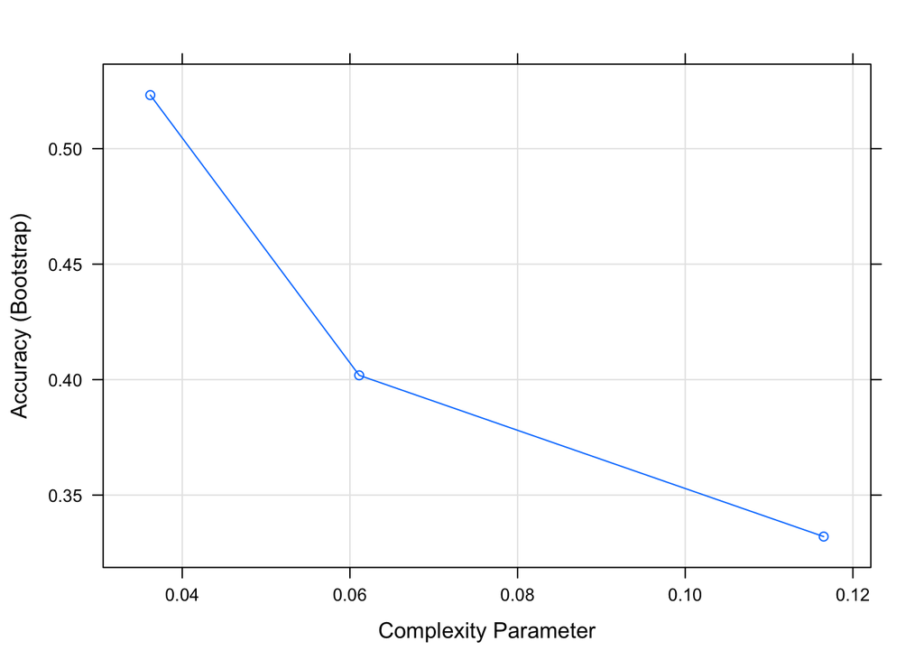

```r
# visualize the relationship between the resampled performance values and the number of PLS components.
plot(modFit)
```

```r
confusionMatrix(data_xval$classe,predict(modFit,data_xval))
```

```
## Confusion Matrix and Statistics
##
##           Reference
## Prediction    A    B    C    D    E
##          A 2029   44  155    0    4
##          B  638  505  375    0    0
##          C  644   49  675    0    0
##          D  567  232  487    0    0
##          E  209  211  383    0  639
##
## Overall Statistics
##
##                Accuracy : 0.4904
##                  95% CI : (0.4793, 0.5016)
##     No Information Rate : 0.5209
##     P-Value [Acc > NIR] : 1
##
##                   Kappa : 0.3339
##  Mcnemar's Test P-Value : NA
##
## Statistics by Class:
##
##                      Class: A Class: B Class: C Class: D Class: E
## Sensitivity            0.4965  0.48511  0.32530       NA  0.99378
## Specificity            0.9460  0.85114  0.87992   0.8361  0.88852
## Pos Pred Value         0.9091  0.33267  0.49342       NA  0.44313
## Neg Pred Value         0.6334  0.91530  0.78388       NA  0.99938
## Prevalence             0.5209  0.13268  0.26447   0.0000  0.08195
## Detection Rate         0.2586  0.06436  0.08603   0.0000  0.08144
## Detection Prevalence   0.2845  0.19347  0.17436   0.1639  0.18379
## Balanced Accuracy      0.7212  0.66812  0.60261       NA  0.94115
```

By default this model used a simple bootstrap resampling method with 11776 samples on 52 predictor.

## Model 2: Random Forest (method = rf)

```r
modFit2 <- train(classe~.,data=data_train,method="rf",trControl = trainControl(method="cv",number=4,allowParallel=TRUE))
print(modFit2)
```

```
## Random Forest
##
## 11776 samples
##    52 predictor
##     5 classes: 'A', 'B', 'C', 'D', 'E'
##
## No pre-processing
## Resampling: Cross-Validated (4 fold)
## Summary of sample sizes: 8831, 8832, 8832, 8833
## Resampling results across tuning parameters:
##
##   mtry  Accuracy   Kappa      Accuracy SD  Kappa SD
##    2    0.9874315  0.9840985  0.003433098  0.004344696
##   27    0.9867525  0.9832417  0.001595396  0.002017260
##   52    0.9802134  0.9749708  0.004036330  0.005103049
##
## Accuracy was used to select the optimal model using  the largest value.
## The final value used for the model was mtry = 2.
```

```r
# show the top 20 most important variables
modFitImp <- varImp(modFit2, scale = FALSE)
modFitImp
```

```
## rf variable importance
##
##   only 20 most important variables shown (out of 52)
##
##                   Overall
## roll_belt           453.2
## yaw_belt            380.0
## magnet_dumbbell_y   309.5
## magnet_dumbbell_z   309.3
## pitch_forearm       302.8
## pitch_belt          300.6
## magnet_dumbbell_x   261.1
## roll_forearm        258.7
## accel_dumbbell_y    238.5
## roll_dumbbell       228.6
## magnet_belt_z       227.0
## magnet_belt_y       225.1
## accel_belt_z        222.4
## accel_dumbbell_z    211.3
## roll_arm            196.4
## accel_forearm_x     189.9
## gyros_dumbbell_y    181.0
## yaw_dumbbell        180.8
## accel_dumbbell_x    179.8
## magnet_arm_x        175.4
```

```r
print(modFit2$finalModel)
```

```
##
## Call:
##  randomForest(x = x, y = y, mtry = param$mtry)
##                Type of random forest: classification
##                      Number of trees: 500
## No. of variables tried at each split: 2
##
##         OOB estimate of  error rate: 0.85%
## Confusion matrix:
##      A    B    C    D    E  class.error
## A 3345    2    0    0    1 0.0008960573
## B   20 2253    6    0    0 0.0114085125
## C    0   23 2029    2    0 0.0121713729
## D    0    0   32 1896    2 0.0176165803
## E    0    0    5    7 2153 0.0055427252
```

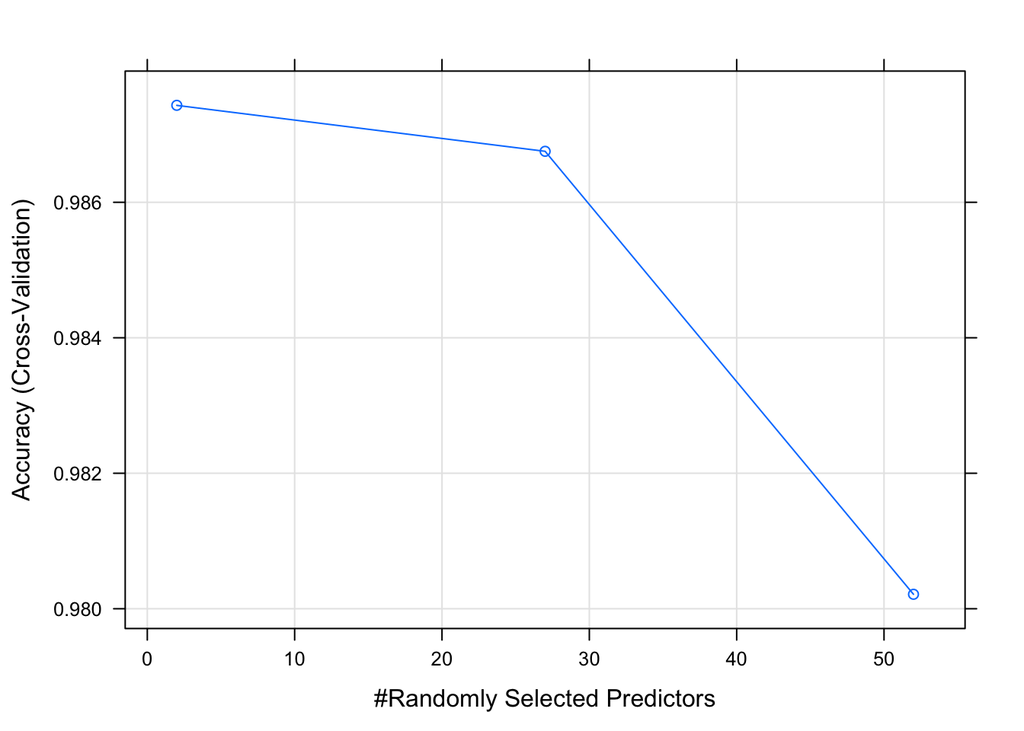

```r
# visualize the relationship between the resampled performance values and the number of PLS components.

plot(modFit2)
```

```r
confusionMatrix(data_xval$classe,predict(modFit2,data_xval))
```

```
## Confusion Matrix and Statistics
##
##           Reference
## Prediction    A    B    C    D    E
##          A 2231    1    0    0    0
##          B    8 1507    3    0    0
##          C    0   11 1353    4    0
##          D    0    0   27 1257    2
##          E    0    0    3    2 1437
##
## Overall Statistics
##
##                Accuracy : 0.9922
##                  95% CI : (0.99, 0.994)
##     No Information Rate : 0.2854
##     P-Value [Acc > NIR] : < 2.2e-16
##
##                   Kappa : 0.9902
##  Mcnemar's Test P-Value : NA
##
## Statistics by Class:
##
##                      Class: A Class: B Class: C Class: D Class: E
## Sensitivity            0.9964   0.9921   0.9762   0.9952   0.9986
## Specificity            0.9998   0.9983   0.9977   0.9956   0.9992
## Pos Pred Value         0.9996   0.9928   0.9890   0.9774   0.9965
## Neg Pred Value         0.9986   0.9981   0.9949   0.9991   0.9997
## Prevalence             0.2854   0.1936   0.1767   0.1610   0.1834
## Detection Rate         0.2843   0.1921   0.1724   0.1602   0.1832
## Detection Prevalence   0.2845   0.1935   0.1744   0.1639   0.1838
## Balanced Accuracy      0.9981   0.9952   0.9869   0.9954   0.9989
```

With a random forest model I do no preprocessing but I do 4 k fold cross validation using the “traincontrol” function. Since we are going to apply a non-parametric model (random forests), no preprocessing is needed to transform the variables because the random forest construction already includes enough subsampling.

Overall accuracy is calculated at just over 99%. The classifier seems to be doing a good job of classifying items. The sensitivity and specificity respectively help us measure the performance of the classifier with all Classes having percentages greater than 95%. The five most important predictors in this model are:roll_belt, yaw_belt, magnet_dumbbell_y, magnet_dumbbell_z, pitch_forearm. The kappa value greater than 0.8 means a statistically perfect model

## Applying Random Forest Model To Test Set

```r
predict_answers <- predict(modFit2,dfcleanDataTest)
print(predict_answers)
```

```
##  [1] B A B A A E D B A A B C B A E E A B B B
## Levels: A B C D E
```

## In Sample & Out of Sample Error

For the selected model (aka Random Forest Model) both the accuracy and the kappa indicator of concordance indicate that the predictor seems to have a low out of sample error rate.

```r
verr <- (1-0.99)
print(verr)
```

```
## [1] 0.01
```

## Conclusion

The random forest model does a good job of predicting activities from accelerometers measurements.